## question1

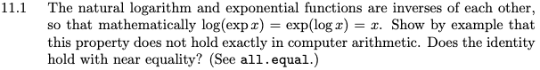

```r
x <- seq(1:10)
y1 <- exp(log(x))
y2 <- log(exp(x))
identical(y1,y2)
```

```
## [1] FALSE
```

```r
all.equal(y1,y2)
```

```
## [1] TRUE
```

## qestion2

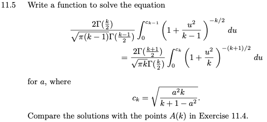

#### the points in Exercise 11.4

```r
k <- c(4:25,100, 500, 1000)
sk <- function(k,a) 1 - pt(sqrt(a^2*k/(k+1-a^2)), df = k)
intersec_sk <- function(k,a) {
  sk(k,a) - sk(k-1,a)
}
solution <- numeric(length(k))
for( i in 1:length(k)){
  m <- k[i]
  n <- sqrt(m-1)
  solution[i] <- uniroot(intersec_sk, k = m, c(0.00001,n + 0.00001))$root
}
knitr::kable(cbind(k,solution))
```

| k | solution |
| --- | --- |
| 4 | 1.492102 |
| 5 | 1.533556 |
| 6 | 1.562727 |
| 7 | 1.584434 |
| 8 | 1.601192 |
| 9 | 1.614519 |
| 10 | 1.625383 |
| 11 | 1.634385 |
| 12 | 1.642026 |
| 13 | 1.648556 |
| 14 | 1.654169 |
| 15 | 1.659096 |
| 16 | 1.663433 |
| 17 | 1.667285 |
| 18 | 1.670707 |
| 19 | 1.673830 |
| 20 | 1.676638 |
| 21 | 1.679131 |
| 22 | 1.681456 |
| 23 | 1.683583 |
| 24 | 1.685541 |
| 25 | 1.687345 |
| 100 | 9.949884 |
| 500 | 22.338318 |
| 1000 | 31.606971 |

#### the points in Exercise 11.5

```r
ck <- function(k,a) sqrt(a^2*k/(k+1-a^2))
f1 <- function(k,a) {
  cka <- ck(k-1,a)
  co <- exp(lgamma(k/2)-lgamma((k-1)/2))/sqrt(k-1)
  f <- function(k,u) (1+(u^2)/(k-1))^(-k/2)
  int <- integrate(f, lower = 0, upper = cka ,k=k)$value
  return(co*int)
}
f2 <- function(k,a){
  cka <- ck(k,a)
  co <- exp(lgamma((k+1)/2)-lgamma(k/2))/sqrt(k)
  f <- function(k,u) (1+(u^2)/(k))^(-k/2-0.5)
  int <- integrate(f, lower = 0, upper = cka ,k=k)$value
  return(co*int)
}

solv <- function(k,a){
  f1(k,a) - f2(k,a)
}
k <- c(4:25,100, 500, 1000)
solution1 <- numeric(length(k))
for( i in 1:length(k)){
  m <- k[i]
  n <- sqrt(m-1)
  upp <- n
  tol <- 10^(-5)
  if(abs(solv(m,upp)) <= tol) solution1[i] <- upp
  else solution1[i] <- uniroot(solv, k = m,c(0.00001,upp), tol = 10^(-5) )$root
}
knitr::kable(cbind(k,solution,solution1))
```

| k | solution | solution1 |
| --- | --- | --- |
| 4 | 1.492102 | 1.492102 |
| 5 | 1.533556 | 1.533556 |
| 6 | 1.562727 | 1.562745 |
| 7 | 1.584434 | 1.584429 |
| 8 | 1.601192 | 1.601182 |
| 9 | 1.614519 | 1.614517 |
| 10 | 1.625383 | 1.625383 |
| 11 | 1.634385 | 1.634409 |
| 12 | 1.642026 | 3.316625 |
| 13 | 1.648556 | 3.464102 |
| 14 | 1.654169 | 3.605551 |
| 15 | 1.659096 | 3.741657 |
| 16 | 1.663433 | 3.872983 |
| 17 | 1.667285 | 4.000000 |
| 18 | 1.670707 | 4.123106 |
| 19 | 1.673830 | 4.242641 |
| 20 | 1.676638 | 4.358899 |
| 21 | 1.679131 | 4.472136 |
| 22 | 1.681456 | 4.582576 |
| 23 | 1.683583 | 4.690416 |
| 24 | 1.685541 | 4.795832 |
| 25 | 1.687345 | 4.898980 |
| 100 | 9.949884 | 9.949874 |
| 500 | 22.338318 | 22.338308 |
| 1000 | 31.606971 | 31.606961 |

## qestion3

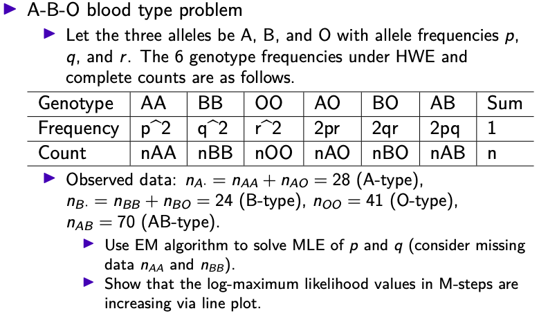

- Observed data likelihood

$$L(p,q|n_{A.},n_{B.},n_{OO},n_{AB})=(p^2+2p(1-p-q))^{n_{A.}}
(q^2+2q(1-p-q))^{n_{B.}}((1-p-q)^2)^{n_{OO}}(2pq)^{n_{AB}}$$

- Complete data likelihood

$$L(p,q|n_{AA},n_{AO},n_{BB},n_{BO},n_{OO}.n_{AB})=(p^2)^{n_{AA}}(2p(1-p-q))^{n_{AO}}(q^2)^{n_{BB}}(2q(1-p-q))^{n_{BO}}((1-p-q)^2)^{n_{OO}}(2pq)^{n_{AB}}$$

$$l(p,q|n_{AA},n_{AO},n_{BB},n_{BO},n_{OO}.n_{AB}) \propto 2n_{AA}log(p)+n_{AO}log(p(1-p-q))+
2n_{BB}log(q)+n_{BO}log(q(1-p-q))+2n_{OO}log(1-p-q)+n_{AB}log(pq)$$

- $$l(p,q|n_{AA},n_{AO},n_{BB},n_{BO},n_{OO}.n_{AB}) \propto n_{AA}log(\frac{p}{1-p-q})+n_{A.}log(p(1-p-q))+
  n_{BB}log(\frac{q}{1-p-q})+n_{B.}log(q(1-p-q))+2n_{OO}log(1-p-q)+n_{AB}log(pq)$$

  in which $n_{AA}$ and $n_{BB}$ are unknown.

- initial step : set $\hat{p}_0$ and $\hat{q}_0$.
- E-step : take $\hat{n}_{AA}=n_{A.}\frac{\hat{p}_0}{2-\hat{p}_0-2\hat{q}_0}$ and $\hat{n}_{BB}=n_{B.}\frac{\hat{q}_0}{2-\hat{q}_0-2\hat{p}_0}$ into the expectational log-likelihood function:
  $$E_{\hat{p}_0,\hat{q}_0}[l(p,q|n_ {AA},n_{AO},n_{BB},n_{BO},n_{OO}.n_{AB})] \propto n_{A.}\frac{\hat{p}_0}{2-\hat{p}_0-2\hat{q}_0}log(\frac{p}{1-p-q})+n_{A.}log(p(1-p-q))+$$
  $$n_{B.}\frac{\hat{q}_0}{2-\hat{q}_0-2\hat{p}_0}log(\frac{q}{1-p-q})+
  n_{B.}log(q(1-p-q))+2n_{OO}log(1-p-q)+n_{AB}log(pq)$$

and here we set $k1=n_{A.}\frac{\hat{p}_0}{2-\hat{p}_0-2\hat{q}_0}$, $k_2=n_{A.}$, $k_3=n_{B.}\frac{\hat{q}_0}{2-\hat{q}_0-2\hat{p}_0}$, $k_4=n_{B.}$, $k_5=n_{OO}$, $k_6=n_{AB}$, then set $a=k_1+k_2+k_6$, $b=k_2+k_4+k_5-k_1-k_3$, $c=k_3+k_4+k_6$. - M-step : maximize the function in E-step to get the estimate of $p$ and $q$:
$$\hat{p}_1= \frac{a}{a+b+c}$$
$$\hat{q}_1= \frac{c}{a+b+c}$$

```r
na <- 28
nb <- 24
no <- 41
nab <- 70
L <- c(0.3,0.3)
N <- 10000
tol <- .Machine$double.eps^0.5
L.old <- L

logml <- numeric()

for(j in 1:N){
  naa <- na*L.old[1]/(2-L.old[1]-2*L.old[2])
  nbb <- nb*L.old[2]/(2-L.old[2]-2*L.old[1])
  a <- naa + na + nab
  c <- nbb + nb + nab
  b <- na + nb + no - naa - nbb
  L <- c(a/(a+b+c), c/(a+b+c))
  logml[j] <- a*log(L[1])+c*log(L[2])+b*log(1-L[1]-L[2])#+log(2)*(nab+na+nb-naa-nbb)

  if (sum((L - L.old)^2) < tol) break
  L.old <- L
}

result <- list()
result$interate <- j ##the times for interation
result$p <- L[1]  ##the estimate of p
result$q <- L[2]  ##the estimate of q
result$logml <- logml ## the maximum of the log-likelihood of each interation
result
```

```
## $interate
## [1] 6
##
## $p
## [1] 0.3869614
##
## $q
## [1] 0.3655958
##
## $logml
## [1] -310.9075 -308.8053 -308.2253 -308.0819 -308.0472 -308.0388
```

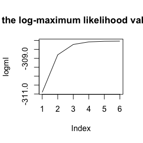

```r
plot(logml,type="l",main = "the log-maximum likelihood values")
```